# Help File

AA

Friday, September 25, 2015

Scenario:

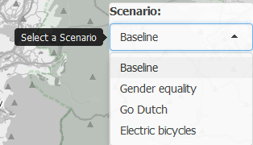

Zone Attribute

1. Scenario Level of Cycling is the model predicted rate of cycling in the given area for the chosen scenario
2. Scenario Increase in Cycling is the corresponding number of additional cycle commuters over and above Census 2011
3. None: No zone attribute is displayed

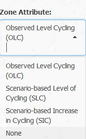

Cycling Flows

1. Straight Lines between the population weighted centroids of Census Medium Super Output Areas
2. ‘Fastest’ Route using [Cycle Streets Routing](http://www.cyclestreets.net/journey/help/howitworks/)
3. ‘Fastest’ and ‘Quietest’ Routes using Cycle Streets Routing

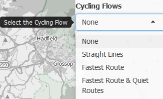

Freeze Lines

1. Ticked: The top cycling flows shown remain those calculated based on the visible map area when the box was ticked
2. Unticked: If the visible map area changes, flows are recalculated accordingly

Line Attribute

1. Scenario Level of Cycling is the model predicted rate of cycling between an origin destination pair for the chosen scenario
2. Scenario Increase in Cycling is the corresponding number of additional cycle commuters that can be expected between the origin destination pair

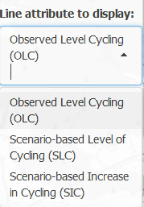

Flows to Show  
When viewing flows, this slider selects how many of the of the top 50 are shown

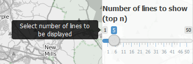

1. Total commutes 2011: The total number of commuting trips between these two zones
2. Cycling 2011: Reported cycle commutes between these two zones
3. Scenario Cycling: The model predicted rate of cycling between an origin destination pair for the chosen scenario
4. Scenario Increase: The difference between the Census 2011 Cycling and the Scenario
5. Route Distance: The route distance in km between the centre of the zones

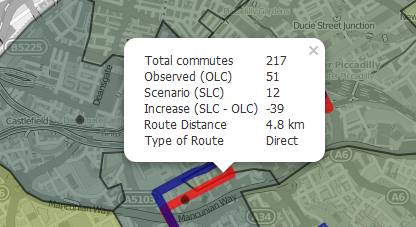

1. Total commutes 2011: The total number of commuting trips between these two zones
2. Cycling 2011: Reported cycle commutes between these two zones
3. Scenario Cycling: The model predicted rate of cycling between an origin destination pair for the chosen scenario
4. Scenario Increase: The difference between the Census 2011 Cycling and the Scenario
5. Route Distance: The route distance in km between the centre of the zones

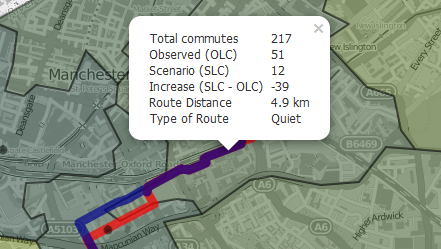

Straight Lines The red line represents a straight line between the population weighted centroid of two zones. Once selected the following information is displayed:

1. Total commutes 2011: The total number of commuting trips between these two zones
2. Cycling 2011: Reported cycle commutes between these two zones
3. Scenario Cycling: The model predicted rate of cycling between an origin destination pair for the chosen scenario
4. Scenario Increase: The difference between the Census 2011 Cycling and the Scenario
5. Route Distance: The route distance in km between the centre of the zones

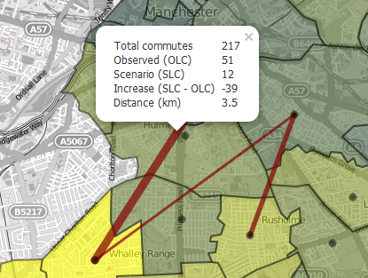

Zone Information Zone information is displayed on clicking on the black circle in the centre of each zone:

1. Zone: Zone name according to the Census
2. Scenario Level of Cycling: the model predicted rate of cycling in the given area for the chosen scenario
3. Scenario Increase in Cycling: the corresponding number of additional cycle commuters over and above Census 2011
4. Hilliness: Shows the average hilliness of the zone from [digital elevation model](http://srtm.csi.cgiar.org/) data supplied by NASA.

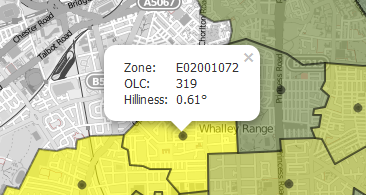

Zone Attribute Legend The legend shows quartiles for the displayed zone attribute according to the scenario selected.

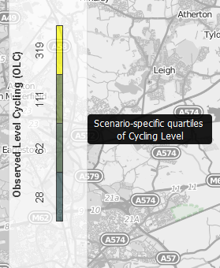